# Assignment 2

DATA 311

Author

Noah Semashkewich - 53882783

# Assignment 2

## **Exploratory / Pre-processing**

### Exercise 1)

The Telco Customer Churn prediction task is a **classification** and **supervised learning** problem.

- This is a **classification** problem because the goal is to predict whether a customer will churn (leave the service) or not, which is a binary outcome.
- This is a **supervised learning** problem because we are provided with labeled data (the target variable is whether the customer churned or not), so it is a supervised learning task.

### Exercise 2)

```r
telco_data = read.csv("Telco-Customer-Churn.csv")

telco_data$tenure = as.numeric(telco_data$tenure)
telco_data$SeniorCitizen = as.factor(telco_data$SeniorCitizen)
telco_data$gender = as.factor(telco_data$gender)
telco_data$Partner = as.factor(telco_data$Partner)
telco_data$Dependents = as.factor(telco_data$Dependents)
telco_data$PhoneService = as.factor(telco_data$PhoneService)
telco_data$MultipleLines = as.factor(telco_data$MultipleLines)
telco_data$InternetService = as.factor(telco_data$InternetService)
telco_data$OnlineSecurity = as.factor(telco_data$OnlineSecurity)
telco_data$OnlineBackup = as.factor(telco_data$OnlineBackup)
telco_data$DeviceProtection = as.factor(telco_data$DeviceProtection)
telco_data$TechSupport = as.factor(telco_data$TechSupport)
telco_data$StreamingTV = as.factor(telco_data$StreamingTV)
telco_data$StreamingMovies = as.factor(telco_data$StreamingMovies)
telco_data$Contract = as.factor(telco_data$Contract)
telco_data$PaperlessBilling = as.factor(telco_data$PaperlessBilling)
telco_data$PaymentMethod = as.factor(telco_data$PaymentMethod)
telco_data$Churn = as.factor(telco_data$Churn)
telco_data$TotalCharges = as.numeric(telco_data$TotalCharges)
telco_data = na.omit(telco_data)

str(telco_data)
```

```
'data.frame':   7032 obs. of  21 variables:
 $ customerID      : chr  "7590-VHVEG" "5575-GNVDE" "3668-QPYBK" "7795-CFOCW" ...
 $ gender          : Factor w/ 2 levels "Female","Male": 1 2 2 2 1 1 2 1 1 2 ...
 $ SeniorCitizen   : Factor w/ 2 levels "0","1": 1 1 1 1 1 1 1 1 1 1 ...
 $ Partner         : Factor w/ 2 levels "No","Yes": 2 1 1 1 1 1 1 1 2 1 ...
 $ Dependents      : Factor w/ 2 levels "No","Yes": 1 1 1 1 1 1 2 1 1 2 ...
 $ tenure          : num  1 34 2 45 2 8 22 10 28 62 ...
 $ PhoneService    : Factor w/ 2 levels "No","Yes": 1 2 2 1 2 2 2 1 2 2 ...
 $ MultipleLines   : Factor w/ 3 levels "No","No phone service",..: 2 1 1 2 1 3 3 2 3 1 ...
 $ InternetService : Factor w/ 3 levels "DSL","Fiber optic",..: 1 1 1 1 2 2 2 1 2 1 ...
 $ OnlineSecurity  : Factor w/ 3 levels "No","No internet service",..: 1 3 3 3 1 1 1 3 1 3 ...
 $ OnlineBackup    : Factor w/ 3 levels "No","No internet service",..: 3 1 3 1 1 1 3 1 1 3 ...
 $ DeviceProtection: Factor w/ 3 levels "No","No internet service",..: 1 3 1 3 1 3 1 1 3 1 ...
 $ TechSupport     : Factor w/ 3 levels "No","No internet service",..: 1 1 1 3 1 1 1 1 3 1 ...
 $ StreamingTV     : Factor w/ 3 levels "No","No internet service",..: 1 1 1 1 1 3 3 1 3 1 ...
 $ StreamingMovies : Factor w/ 3 levels "No","No internet service",..: 1 1 1 1 1 3 1 1 3 1 ...
 $ Contract        : Factor w/ 3 levels "Month-to-month",..: 1 2 1 2 1 1 1 1 1 2 ...
 $ PaperlessBilling: Factor w/ 2 levels "No","Yes": 2 1 2 1 2 2 2 1 2 1 ...
 $ PaymentMethod   : Factor w/ 4 levels "Bank transfer (automatic)",..: 3 4 4 1 3 3 2 4 3 1 ...
 $ MonthlyCharges  : num  29.9 57 53.9 42.3 70.7 ...
 $ TotalCharges    : num  29.9 1889.5 108.2 1840.8 151.7 ...
 $ Churn           : Factor w/ 2 levels "No","Yes": 1 1 2 1 2 2 1 1 2 1 ...
 - attr(*, "na.action")= 'omit' Named int [1:11] 489 754 937 1083 1341 3332 3827 4381 5219 6671 ...
  ..- attr(*, "names")= chr [1:11] "489" "754" "937" "1083" ...
```

### Exercise 3)

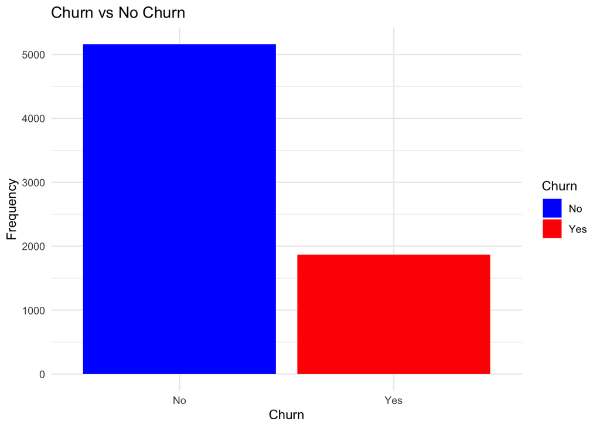

```r
library(ggplot2)
ggplot(telco_data, aes(x = Churn, fill = Churn)) +
  geom_bar() +
  labs(title = "Churn vs No Churn", x = "Churn", y = "Frequency") +
  scale_fill_manual(values = c("No" = "blue", "Yes" = "red")) +  # Blue for "No" and red for "Yes"
  theme_minimal()
```

The plot suggests that this data set is imbalanced as there is a significantly higher amount of “No” than there is “Yes”. What this implies for modeling:

- Model Bias Towards Majority Class: With most customers classified as “No”, the model may lean towards predicting the majority class more often, which can overlook the minority (churners).
- Poor Recall in Minority Class: Imbalance can lead to poor recall for the minority class (“Yes”), meaning the model may not correctly identify all the customers who are likely to churn.
- Misleading Accuracy: Model may have a misleading accuracy due to the imbalance. i.e. if the model predicts “No” churn for every case, it could still achieve a very high accuracy just by predicting the majority class.

### Exercise 4)

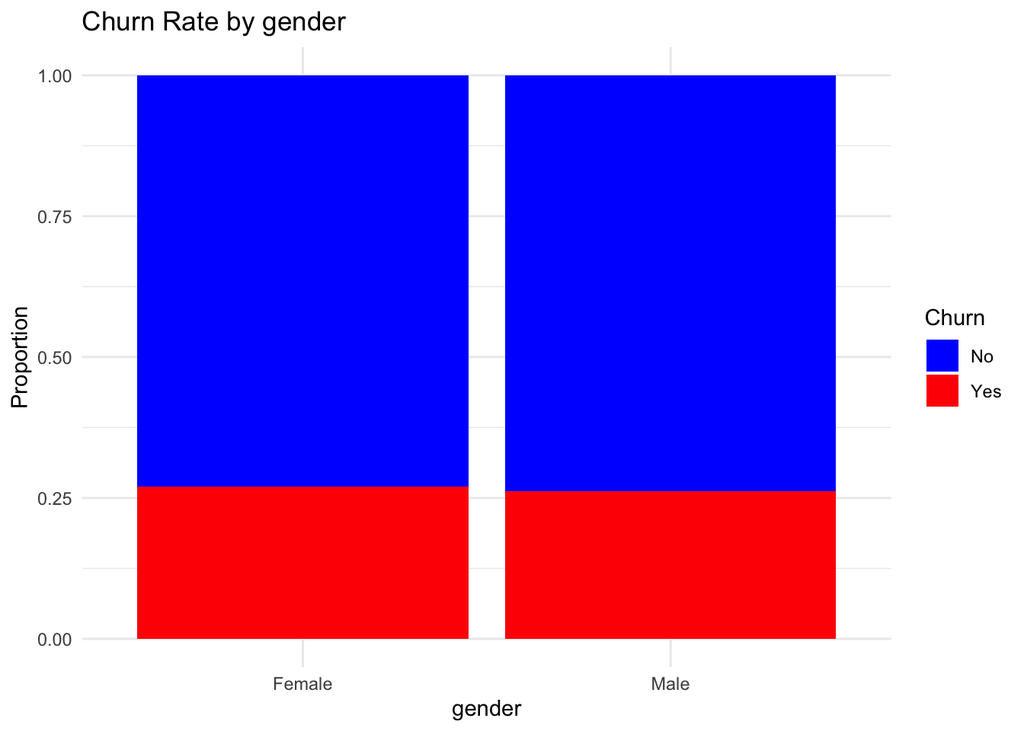

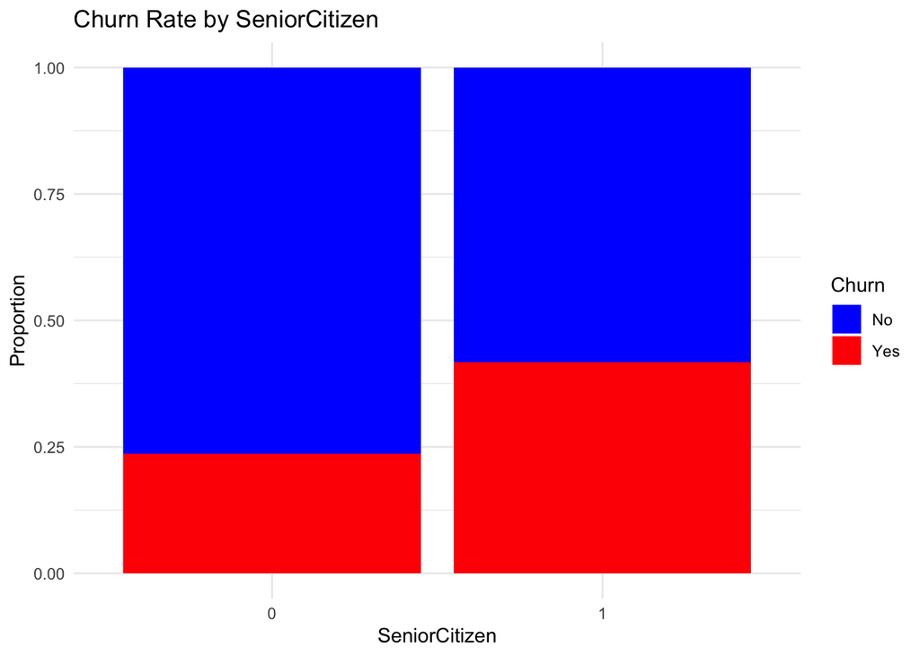

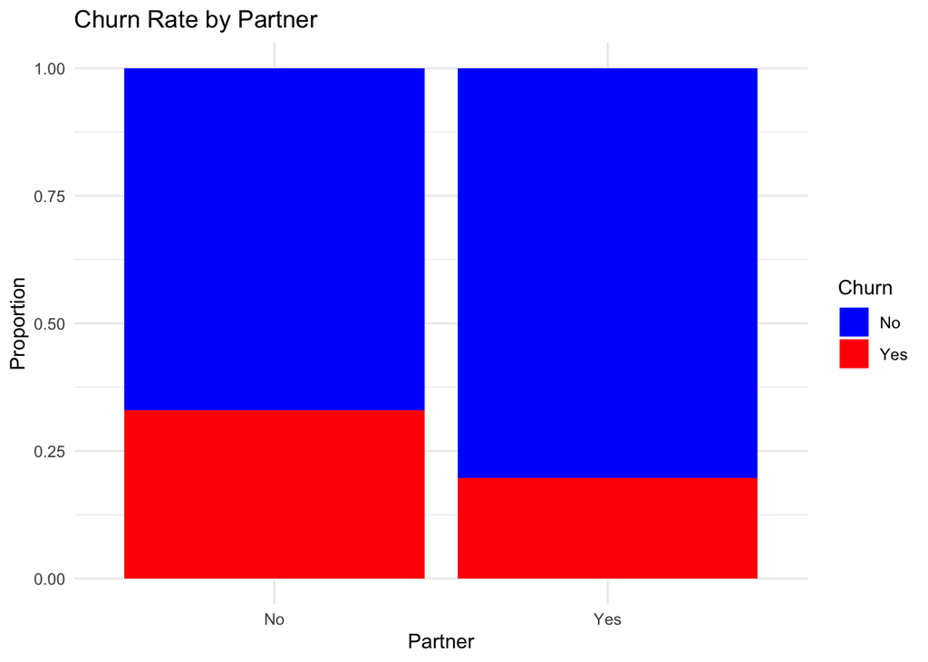

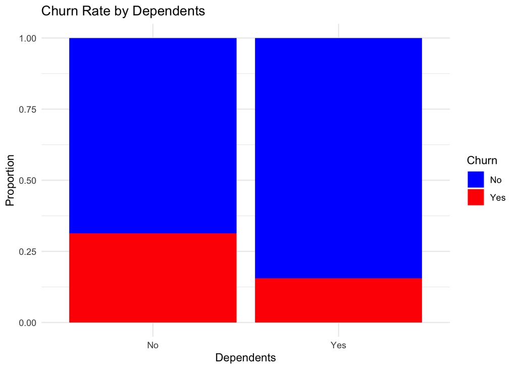

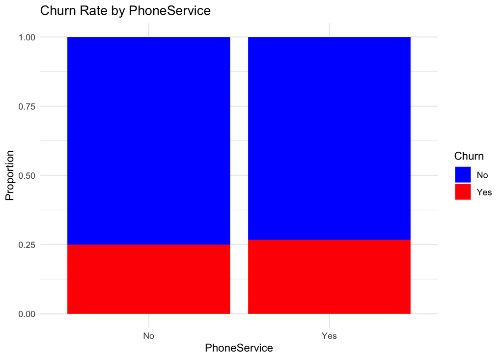

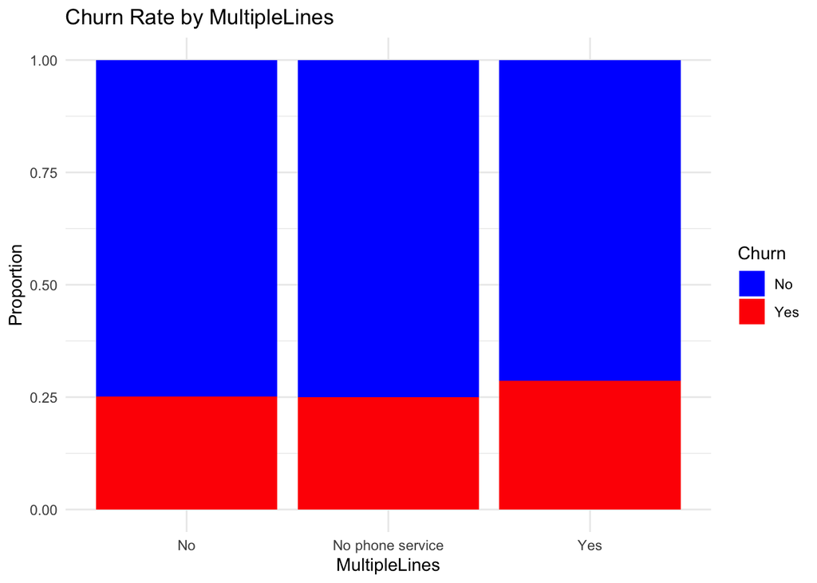

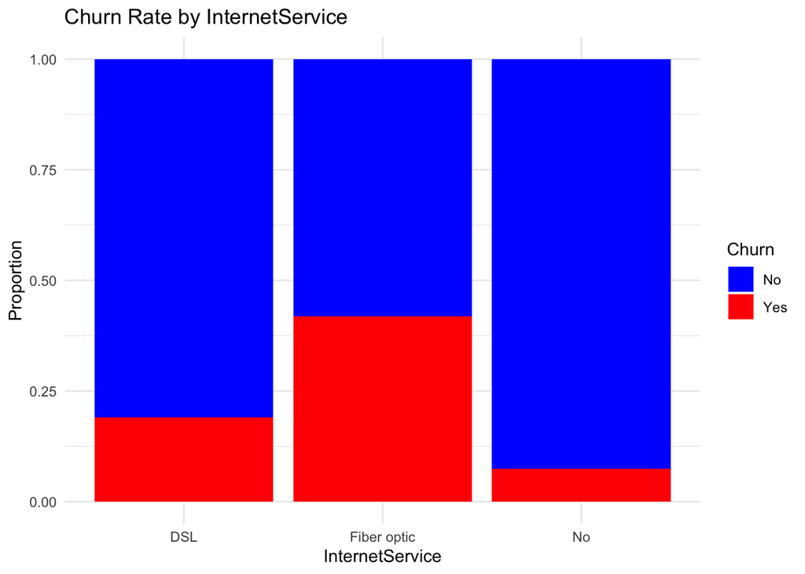

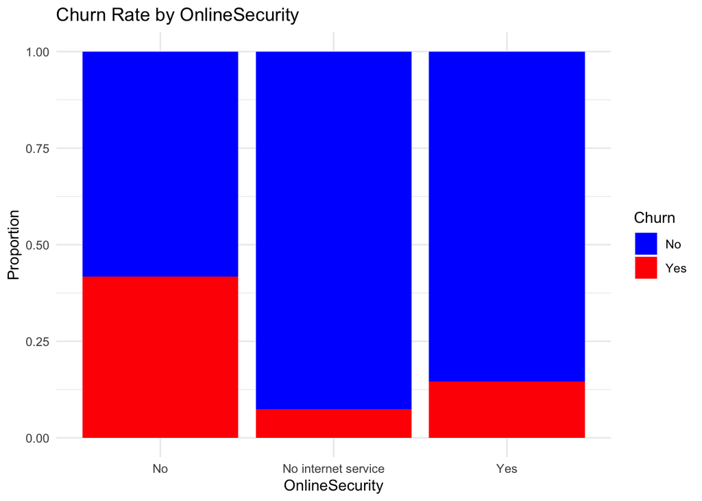

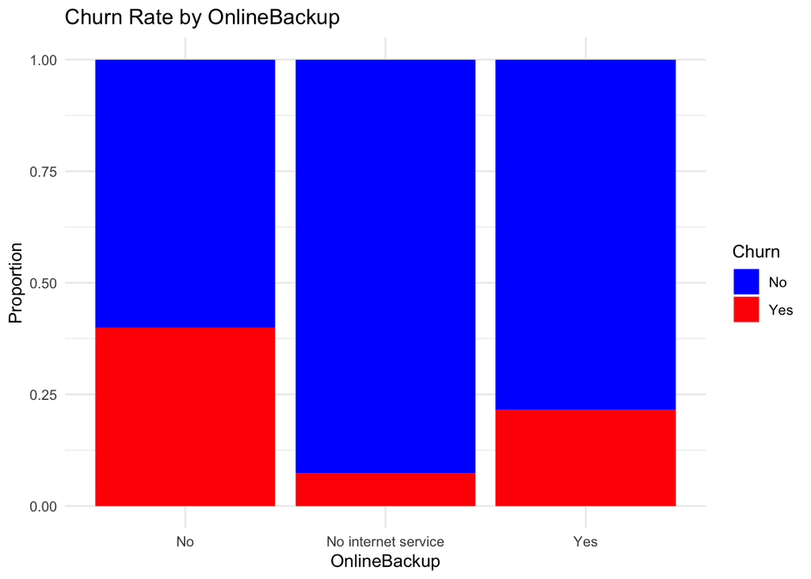

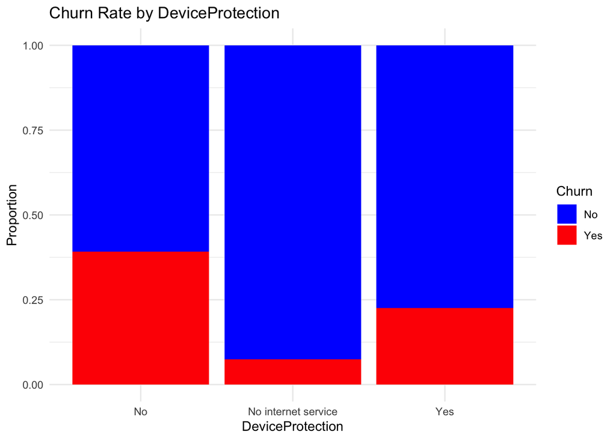

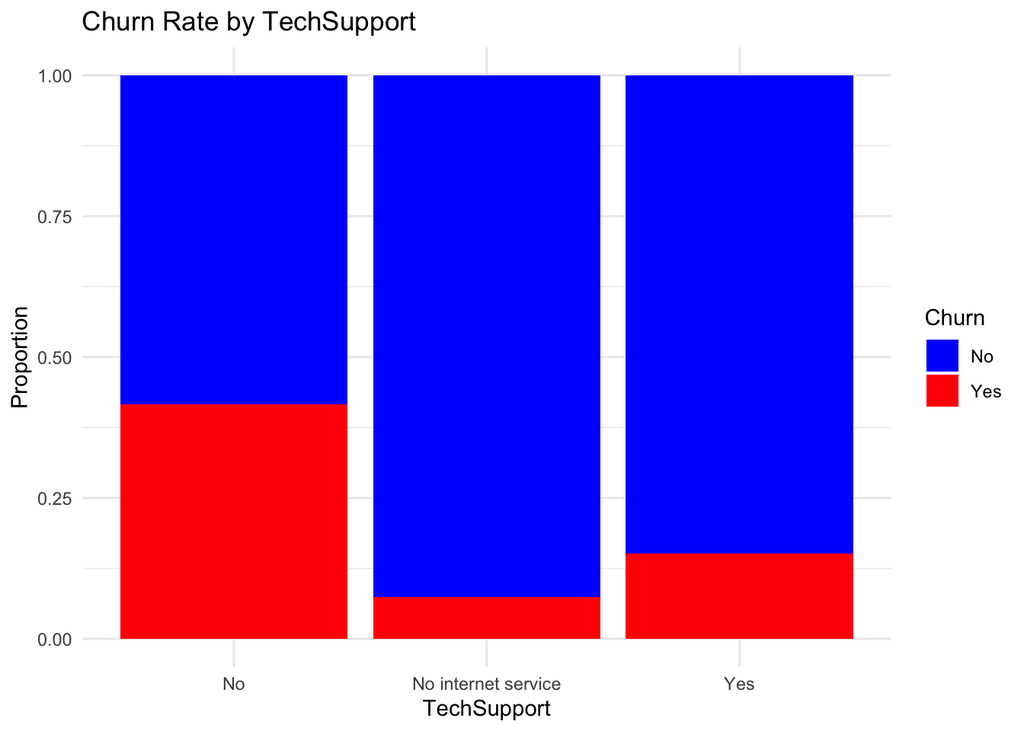

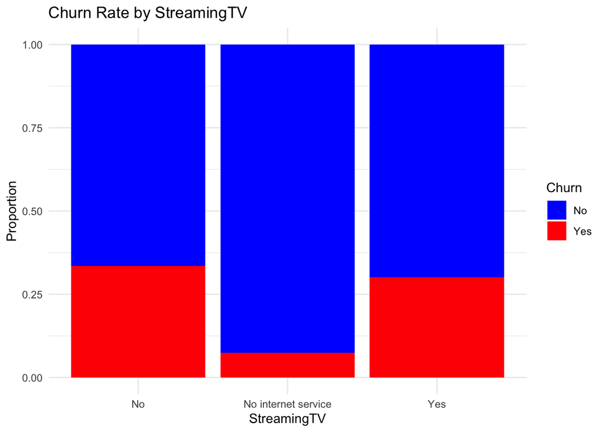

[4 more figures not shown]

```r
library(ggplot2)

# Function to plot churn rate by a given predictor
churnPlot = function(predictor) {
  ggplot(telco_data, aes(x = .data[[predictor]], fill = Churn)) +
    geom_bar(position = "fill") +
    labs(title = paste("Churn Rate by", predictor), x = predictor, y = "Proportion") +
    scale_fill_manual(values = c("No" = "blue", "Yes" = "red")) + theme_minimal()
}

# List of predictors (excluding specified columns)
predictors = colnames(telco_data)
exclude_columns = c("customerID", "Churn","TotalCharges", "MonthlyCharges", "tenure","tenure_bins","total_bins","monthly_bins")
predictors = predictors[!predictors %in% exclude_columns]

# Looping through each predictor and generate the churn plot
for (predictor in predictors) {
  print(churnPlot(predictor))
}
```

Interpretation: Based on the plots created, the significant predictors that are associated with Churn are SeniorCitizen, Partner, Dependents, InternetService, OnlineSecuirity, OnlineBackup, DeviceProtection, TechSupport, Contract, PaperlessBilling, and PaymentMethod.

### Exercise 5)

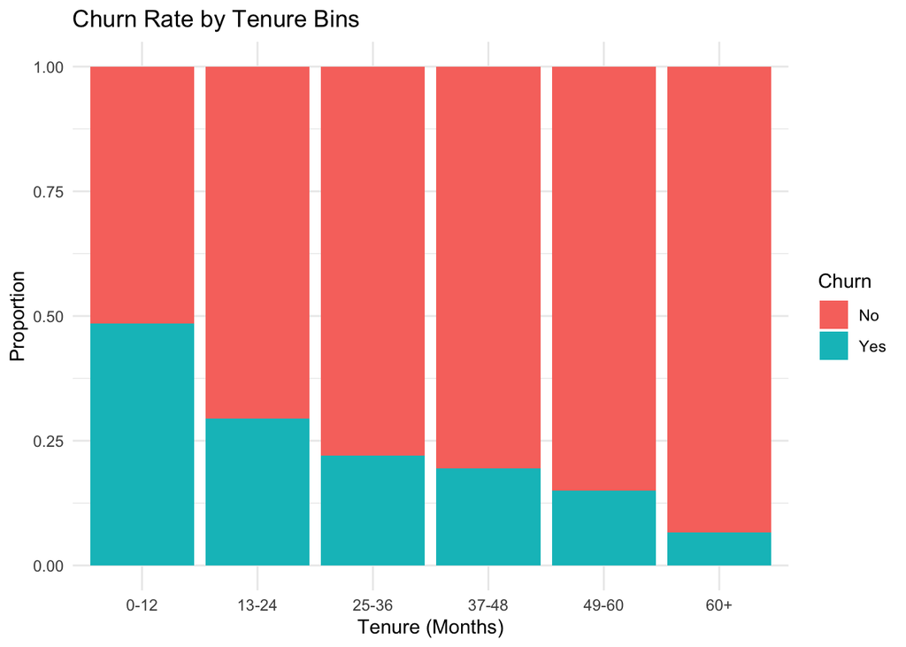

```r
library(ggplot2)

# Create binned tenure categories
telco_data$tenure_bins = cut(telco_data$tenure,
                         breaks = c(0, 12, 24, 36, 48, 60, Inf),
                         labels = c("0-12", "13-24", "25-36", "37-48", "49-60", "60+"),
                         right = FALSE,   # Include the lower bound, exclude the upper
                         include.lowest = TRUE)  # Include the lowest value

# Plot
ggplot(telco_data, aes(x = tenure_bins, fill = Churn)) +
    geom_bar(position = "fill") +
    labs(title = "Churn Rate by Tenure Bins", x = "Tenure (Months)", y = "Proportion") +
    theme_minimal()
```

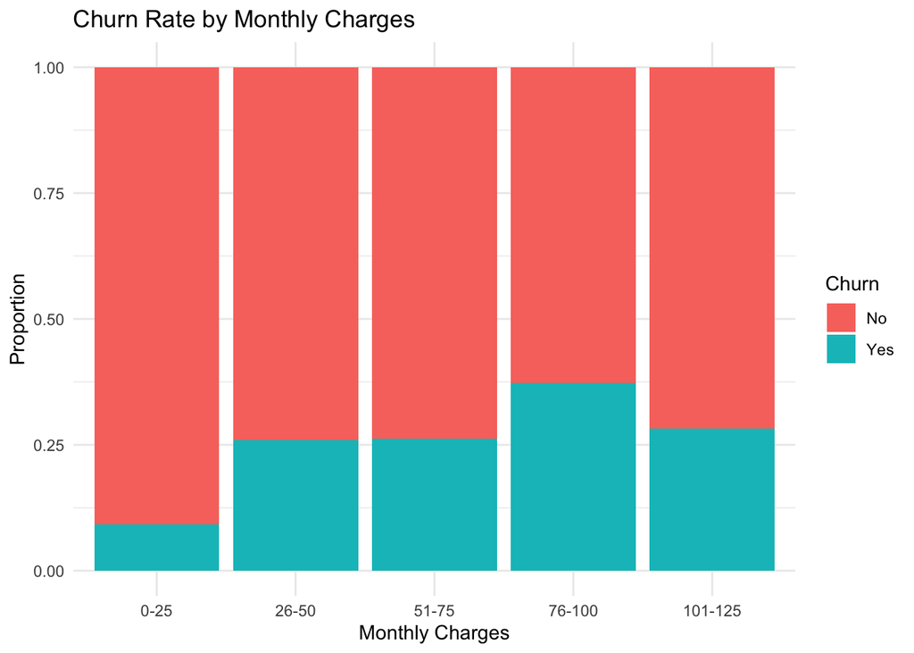

```r
# Create binned MonthlyCharges categories
telco_data$monthly_bins = cut(telco_data$MonthlyCharges,
                          breaks = c(0, 25, 50, 75, 100, 125, Inf),
                          labels = c("0-25", "26-50", "51-75", "76-100", "101-125", "125+"),
                          right = FALSE,
                          include.lowest = TRUE)

# Bar plot for MonthlyCharges
ggplot(telco_data, aes(x = monthly_bins, fill = Churn)) +
    geom_bar(position = "fill") +
    labs(title = "Churn Rate by Monthly Charges", x = "Monthly Charges", y = "Proportion") +
    theme_minimal()
```

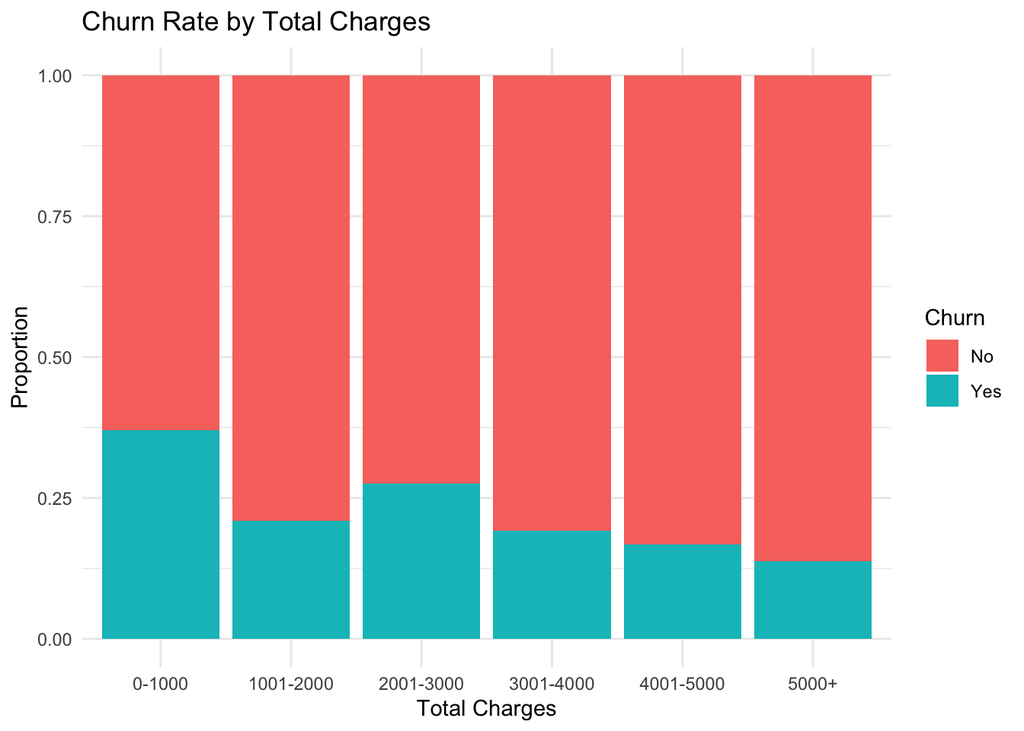

```r
# Create binned TotalCharges categories
telco_data$total_bins = cut(telco_data$TotalCharges,
                        breaks = c(0, 1000, 2000, 3000, 4000, 5000, Inf),
                        labels = c("0-1000", "1001-2000", "2001-3000", "3001-4000", "4001-5000", "5000+"),
                        right = FALSE,
                        include.lowest = TRUE)

# Bar plot for TotalCharges
ggplot(telco_data, aes(x = total_bins, fill = Churn)) +
    geom_bar(position = "fill") +
    labs(title = "Churn Rate by Total Charges", x = "Total Charges", y = "Proportion") +
    theme_minimal()
```

Interpretation:

- **Tenure**: Customers with lower tenure (0-12 months) tend to churn more frequently than those with higher tenure, suggesting that tenure is inversely related to churn.
- **Monthly Charges**: Customers who pay higher monthly charges (76-100) seem to be associated with increased churn rates, suggesting those who pay in this range may be more likely to leave.
- **Total Charges**: Total charges show a trend where customers with lower total charges tend to churn more often, possibly indicating dissatisfaction early in the customer life cycle.

After interpretation, we can see that tenure, monthly charges, and total charges are all associated with churn.

### Exercise 6)

```r
set.seed(53882783)
library(caTools)

# 70% training, 30% test split
sampleSize = floor(0.7 * nrow(telco_data))
set = sample(seq_len(nrow(telco_data)), size = sampleSize)

train_set = telco_data[set, ]
test_set = telco_data[-set, ]

# Check dimensions of the datasets
dim(train_set)
```

```
[1] 4922   24
```

```r
dim(test_set)
```

```
[1] 2110   24
```

## **Model Fitting**

### Exercise 7)

```r
set.seed(53882783)
library(dplyr)
# Train the logistic regression model
log_model = glm(Churn ~ tenure + MonthlyCharges + TotalCharges,
                      data = train_set,
                      family = binomial)

# Summary of model
summary(log_model)
```

```
Call:
glm(formula = Churn ~ tenure + MonthlyCharges + TotalCharges,
    family = binomial, data = train_set)

Deviance Residuals:
    Min       1Q   Median       3Q      Max
-1.7515  -0.7183  -0.4069   0.7718   2.9783

Coefficients:
                 Estimate Std. Error z value Pr(>|z|)
(Intercept)    -1.653e+00  1.424e-01 -11.611   <2e-16 ***
tenure         -6.455e-02  6.534e-03  -9.880   <2e-16 ***
MonthlyCharges  3.043e-02  2.067e-03  14.723   <2e-16 ***
TotalCharges    1.139e-04  7.371e-05   1.545    0.122
---
Signif. codes:  0 '***' 0.001 '**' 0.01 '*' 0.05 '.' 0.1 ' ' 1

(Dispersion parameter for binomial family taken to be 1)

    Null deviance: 5627.1  on 4921  degrees of freedom
Residual deviance: 4407.3  on 4918  degrees of freedom
AIC: 4415.3

Number of Fisher Scoring iterations: 6
```

### Exercise 8)

Interpretation of coefficients:

- **Intercept (−1.653):** The intercept represents the expected log-odds of churn when all predictors (tenure, MonthlyCharges, and TotalCharges) are equal to zero. However, since a customer cannot have zero tenure or charges, this value serves as a baseline for our model. The negative value suggests that, on average, customers are less likely to churn.
- **Tenure (−0.06455):** For each additional month of tenure, the log-odds of churn decrease by 0.06455, holding all other variables constant. This negative coefficient indicates that customers with longer tenure are significantly less likely to churn. Each additional month of tenure reduces the likelihood of churn, suggesting that longer-term customers exhibit greater loyalty to the service.
- **MonthlyCharges (0.03043):** For each additional dollar increase in MonthlyCharges, the log-odds of churn increase by 0.03043, holding all other variables constant. This positive coefficient suggests that as monthly charges increase, customers are more likely to churn. Higher charges may lead to feelings of dissatisfaction or a perception of being overcharged for the service.
- **TotalCharges (0.0001139):** For each additional dollar increase in TotalCharges, the log-odds of churn increase by 0.0001139, holding all other variables constant. Similar to MonthlyCharges, the positive coefficient indicates that as the total amount charged to the customer increases, the likelihood of churn also increases. This suggests that customers who perceive higher total costs over time may be more inclined to leave the service.

### Exercise 9)

```r
set.seed(53882783)
# Fitting new logistic regression model with previous predictors + InternetService
log_model_v2 = glm(Churn ~ tenure + TotalCharges + Contract + InternetService,
                    data = train_set,
                       family = binomial)

# Display model summary
summary(log_model_v2)
```

```
Call:
glm(formula = Churn ~ tenure + TotalCharges + Contract + InternetService,
    family = binomial, data = train_set)

Deviance Residuals:
    Min       1Q   Median       3Q      Max
-1.5018  -0.7101  -0.3055   0.8862   3.3983

Coefficients:
                             Estimate Std. Error z value Pr(>|z|)
(Intercept)                -1.702e-01  8.716e-02  -1.953 0.050873 .
tenure                     -5.452e-02  6.977e-03  -7.814 5.53e-15 ***
TotalCharges                2.842e-04  7.438e-05   3.821 0.000133 ***
ContractOne year           -9.813e-01  1.262e-01  -7.778 7.34e-15 ***
ContractTwo year           -1.898e+00  2.123e-01  -8.942  < 2e-16 ***
InternetServiceFiber optic  9.339e-01  1.016e-01   9.188  < 2e-16 ***
InternetServiceNo          -1.026e+00  1.446e-01  -7.098 1.26e-12 ***
---
Signif. codes:  0 '***' 0.001 '**' 0.01 '*' 0.05 '.' 0.1 ' ' 1

(Dispersion parameter for binomial family taken to be 1)

    Null deviance: 5627.1  on 4921  degrees of freedom
Residual deviance: 4160.6  on 4915  degrees of freedom
AIC: 4174.6

Number of Fisher Scoring iterations: 6
```

Interpretation of coefficients:

- **Intercept (−0.1702):** The intercept represents the expected log-odds of churn when all predictors (tenure, TotalCharges, Contract, and InternetService) are equal to zero or at their reference categories. The coefficient is marginally significant with a p-value of 0.050873, indicating that it is close to the threshold of significance. The negative value suggests that, on average, customers are less likely to churn when other variables are not influencing the outcome.
- **Tenure (−0.05452):** For each additional month of tenure, the log-odds of churn decrease by 0.05452, holding all other variables constant. This negative coefficient indicates that customers with longer tenure are significantly less likely to churn. The predictor is highly significant with a p-value of 5.53e-15, suggesting that longer-term customers exhibit greater loyalty to the service.
- **TotalCharges (0.0002842):** For each additional dollar increase in TotalCharges, the log-odds of churn increase by 0.0002842, holding all other variables constant. This positive coefficient indicates that higher total charges are associated with a higher likelihood of churn. The predictor is also highly significant with a p-value of 0.000133, suggesting that customers with higher cumulative costs over time are more likely to leave the service.
- **Contract (One Year) (−0.9813):** Customers on a one-year contract are significantly less likely to churn than those on a month-to-month contract. The log-odds of churn decrease by about 0.9813 for one-year contracts. This predictor is highly significant with a p-value of 7.34e-15, indicating that longer contracts correlate with reduced churn rates.
- **Contract (Two Year) (−1.898):** Customers on a two-year contract are significantly less likely to churn compared to those on a month-to-month contract. The log-odds of churn decrease by about 1.898, which is highly significant with a p-value < 2e-16. This indicates that the longer the contract, the lower the likelihood of churn.
- **InternetService (Fiber optic) (0.9339):** Customers with fiber optic service have higher log-odds of churn compared to those with other internet service options, with an increase of about 0.9339. This coefficient is highly significant with a p-value < 2e-16, suggesting that fiber optic customers may have a higher tendency to churn.
- **InternetService (No) (−1.026):** Customers without internet service are significantly less likely to churn compared to those with other internet services, with a log-odds decrease of about 1.026. This predictor is highly significant with a p-value of 1.26e-12, indicating a protective effect against churn for customers without internet service.

### Exercise 10)

```r
library(caret)
library(class)
set.seed(53882783)

control_10fold = trainControl(method = "cv", number = 10)
k_values = data.frame(k = seq(1, 50, by = 1))

knn_model = train(Churn ~ tenure + TotalCharges + Contract + InternetService,
                          data = train_set,
                           method = "knn",
                          trControl = control_10fold,
                           tuneGrid = k_values)

# Display the results
print(knn_model)
```

```
k-Nearest Neighbors

4922 samples
   4 predictor
   2 classes: 'No', 'Yes'

No pre-processing
Resampling: Cross-Validated (10 fold)
Summary of sample sizes: 4429, 4430, 4430, 4430, 4430, 4430, ...
Resampling results across tuning parameters:

  k   Accuracy   Kappa
   1  0.6997213  0.2259185
   2  0.7092729  0.2494210
   3  0.7466519  0.3021659
```

[output cut: 50 more lines]

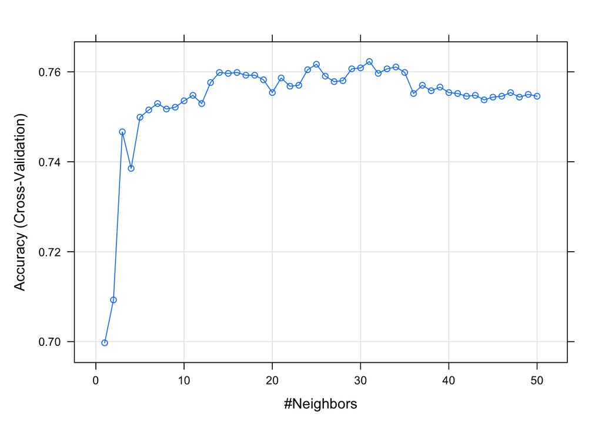

```r
plot(knn_model)
```

The optimal model uses a value of k = 31.

### Exercise 11)

```r
set.seed(53882783)
control_10fold_v2 = trainControl(method = "cv", number = 10)

optimal_k = data.frame(k = knn_model$bestTune$k)
knn_model_v2 = train(Churn ~ tenure + TotalCharges + Contract + InternetService,
                          data = train_set,
                          method = "knn",
                          trControl = control_10fold,
                          tuneGrid = optimal_k)

print(knn_model_v2)
```

```
k-Nearest Neighbors

4922 samples
   4 predictor
   2 classes: 'No', 'Yes'

No pre-processing
Resampling: Cross-Validated (10 fold)
Summary of sample sizes: 4429, 4430, 4430, 4430, 4430, 4430, ...
Resampling results:

  Accuracy   Kappa
  0.7627006  0.2165873

Tuning parameter 'k' was held constant at a value of 31
```

### Exercise 12)

Setting a seed is important in the K-Nearest Neighbors (KNN) algorithm when using methods like cross-validation, data splitting (train/test), or shuffling. These processes involve randomness, and setting a seed ensures reproducibility by controlling the random elements.

- **Data splitting:** When the data is split into training and validation sets (as done in cross-validation), the way this split occurs can be random. By setting a seed, we can ensure that each time the algorithm is run, the splits happen the same way.
- **Cross-validation:** KNN often uses cross-validation to evaluate performance across different subsets of the data. The division of the data into folds involves randomness, which can impact the performance results. A seed ensures the same folds are created each time.

### Exercise 13)

```r
library(MASS)
lda_model = lda(Churn ~ tenure + TotalCharges, data = train_set)

# Display model summary
summary(lda_model)
```

```
        Length Class  Mode
prior   2      -none- numeric
counts  2      -none- numeric
means   4      -none- numeric
scaling 2      -none- numeric
lev     2      -none- character
svd     1      -none- numeric
N       1      -none- numeric
call    3      -none- call
terms   3      terms  call
xlevels 0      -none- list
```

### Exercise 14)

```r
library(MASS)

qda_model = qda(Churn ~ tenure + TotalCharges, data = train_set)

# Display the model summary
summary(qda_model)
```

```
        Length Class  Mode
prior   2      -none- numeric
counts  2      -none- numeric
means   4      -none- numeric
scaling 8      -none- numeric
ldet    2      -none- numeric
lev     2      -none- character
N       1      -none- numeric
call    3      -none- call
terms   3      terms  call
xlevels 0      -none- list
```

## **Evaluation of Classification Models**

### Exercise 15)

```r
# Exercise 7 - log_model
logistic_pred_log_model = predict(log_model, newdata = test_set, type = "response")
logistic_pred_class_log_model = ifelse(logistic_pred_log_model > 0.5, "Yes", "No")
logistic_conf_matrix_log_model = confusionMatrix(factor(logistic_pred_class_log_model), factor(test_set$Churn))
print(logistic_conf_matrix_log_model$table)
```

```
          Reference
Prediction   No  Yes
       No  1388  348
       Yes  126  248
```

```r
# Exercise 9 - log_model_v2
logistic_pred_log_model_v2 = predict(log_model_v2, newdata = test_set, type = "response")
logistic_pred_class_log_model_v2 = ifelse(logistic_pred_log_model_v2 > 0.5, "Yes", "No")
logistic_conf_matrix_log_model_v2 = confusionMatrix(factor(logistic_pred_class_log_model_v2), factor(test_set$Churn))
print(logistic_conf_matrix_log_model_v2$table)
```

```
          Reference
Prediction   No  Yes
       No  1381  329
       Yes  133  267
```

```r
# Exercise 10 - knn_model
knn_predictions = predict(knn_model, newdata = test_set)
knn_conf_matrix = confusionMatrix(knn_predictions, test_set$Churn)
print(knn_conf_matrix$table)
```

```
          Reference
Prediction   No  Yes
       No  1442  461
       Yes   72  135
```

```r
# Exercise 11 - knn_model_v2
knn_pred_v2 = predict(knn_model_v2, newdata = test_set)
knn_conf_matrix_v2 = confusionMatrix(knn_pred_v2, test_set$Churn)
print(knn_conf_matrix_v2$table)
```

```
          Reference
Prediction   No  Yes
       No  1441  461
       Yes   73  135
```

```r
# Exercise 13 - lda_model
lda_pred = predict(lda_model, newdata = test_set)
lda_conf_matrix = confusionMatrix(lda_pred$class, test_set$Churn)
print(lda_conf_matrix$table)
```

```
          Reference
Prediction   No  Yes
       No  1478  487
       Yes   36  109
```

```r
# Exercise 14 - qda_model
qda_pred = predict(qda_model, newdata = test_set)
qda_conf_matrix = confusionMatrix(qda_pred$class, test_set$Churn)
print(qda_conf_matrix$table)
```

```
          Reference
Prediction   No  Yes
       No  1042  167
       Yes  472  429
```

### Exercise 16)

[output not shown]

### Exercise 17)

```r
library(boot)
set.seed(53882783)
# Defining a function to calculate recall
recall_function = function(data, indices) {
  sample_data = data[indices, ]  # Create a bootstrap sample
  predictions = predict(qda_model, newdata = sample_data)  # Use your QDA model
  conf_matrix = confusionMatrix(predictions$class, sample_data$Churn)

  # Calculate recall
  recall = conf_matrix$byClass["Recall"]
  return(recall)
}

# Create a bootstrap sample and calculate recall
boot_results = boot(data = test_set, statistic = recall_function, R = 1000)  # R is the number of bootstrap samples

# Calculate standard deviation of recall
recall_sd = sd(boot_results$t)

# Calculate 95% confidence interval
ci_lower = quantile(boot_results$t, 0.025)
ci_upper = quantile(boot_results$t, 0.975)

# Print results
cat("95% Confidence Interval for Recall:", ci_lower, "-", ci_upper, "\n")
```

```
95% Confidence Interval for Recall: 0.6642459 - 0.712393
```

```r
print(boot_results)
```

```
ORDINARY NONPARAMETRIC BOOTSTRAP


Call:
boot(data = test_set, statistic = recall_function, R = 1000)


Bootstrap Statistics :
     original        bias    std. error
t1* 0.6882431 -0.0005440303  0.01198433
```